# Final Report_Kickstarter

Group G: Tianyi Zhou, Niqian Wu, Lin Wang, Shengchen Fu

12/2/2018

#### 1.Introduction

Kickstarter is an online crowdfunding platform which aims to bring global creative projects to the real world. Each project must clarify its funding goal needed to be reached. Backers will fund the projects they are interested in through Kickstarter. Project teams will offer tangible rewards to their backers in compensation of their funds for the projects. Kickstarter earns profit by charging the successful project teams by 5% of the total pledged amount.

Therefore, Kickstarter can earn more revenue by enhancing projects’ successful rates and by increasing pledged amount of projects. After our analysis, we discovered some insights about Kickstarter and generated several valuable recommendations to Kickstarter.

Our main problem is how can Kickstarter increase its revenue. The sub-problems are what variables lead to successful projects and what variables lead to higher pledge amount of projects.

#### 2.Data Description

**Dataset selection and missing data issue**  
There are 2 datasets from Kickstarter on Kaggle. In the 2016 dataset, there are many observations with data being shifted to the next column, leading to missing data. In the updated 2018 dataset, Kickstarter amended this issue while covering all the same observations as in 2016 as well as additional observations. So, we used the 2018 dataset without the missing data problem and with more information.  
To apply this data to our analysis, we explored the original 2018 dataset and conducted data cleaning.

```r
#to know the variable type of each column
glimpse(df)
```

```
## Observations: 378,661
## Variables: 15
## $ ID               <int> 1000002330, 1000003930, 1000004038, 100000754...
## $ name             <chr> "The Songs of Adelaide & Abullah", "Greeting ...
## $ category         <chr> "Poetry", "Narrative Film", "Narrative Film",...
## $ main_category    <chr> "Publishing", "Film & Video", "Film & Video",...
## $ currency         <chr> "GBP", "USD", "USD", "USD", "USD", "USD", "US...
## $ deadline         <date> 2015-10-09, 2017-11-01, 2013-02-26, 2012-04-...
## $ goal             <dbl> 1000, 30000, 45000, 5000, 19500, 50000, 1000,...
## $ launched         <dttm> 2015-08-11 12:12:28, 2017-09-02 04:43:57, 20...
## $ pledged          <dbl> 0.00, 2421.00, 220.00, 1.00, 1283.00, 52375.0...
## $ state            <chr> "failed", "failed", "failed", "failed", "canc...
## $ backers          <int> 0, 15, 3, 1, 14, 224, 16, 40, 58, 43, 0, 100,...
## $ country          <chr> "GB", "US", "US", "US", "US", "US", "US", "US...
## $ `usd pledged`    <dbl> 0.00, 100.00, 220.00, 1.00, 1283.00, 52375.00...
## $ usd_pledged_real <dbl> 0.00, 2421.00, 220.00, 1.00, 1283.00, 52375.0...
## $ usd_goal_real    <dbl> 1533.95, 30000.00, 45000.00, 5000.00, 19500.0...
```

```r
#selecting variables
df = df %>% select(ID, name, category, main_category, deadline, launched, state, backers,country,usd_goal_real, usd_pledged_real)
#rename
names(df)[10]<-paste("goal")
names(df)[11]<-paste('pledged')
```

There are 15 variables and 378661 observations in the original Kickstarter data(2018). Some variables are more important for us, such as state, backers, main_category, goal and pledged. Here is the introduction to the 11 variables we pick:

- ID: ID of each Kickstarter project
- name: a distinct value for each observation, name of each Kickstarter project
- state: the pledge state of the projects,including successful, failed, suspended, live, canceled and undefined
- main_category:15 main categories of Kickstarter projects
- category: subcategory of main_category
- goal:goal amount in USD
- pledged: pledged amount in USD
- backers: the number of backers supporting one project
- country:the country of the Kickstarter projects
- deadline: deadline for the pledge
- launched: start time for the pledge

To eliminate the currency problem, we kept usd_goal_real and usd_pledged_real and rename them as goal and pledge. For further analysis, we also created a new column goalreachingratio=pledged/goal to see the proportion that one project completed of its pledge goal.

**The conceptual measure types of the different variables**

```r
table = data.frame(matrix(nrow=9,ncol=2));colnames(table) = c("Nominal","Ratio");table[1,]=c("ID",'Goal');table[2,]=c("Name",'Pledged');table[3,]=c("State",'Backers');table[4,]=c("Main_category",'');table[5,]=c("category",' ');table[6,]=c("Currency",' ');table[7,]=c("Country",' ');table[8,]=c("Deadline",' ');table[9,]=c("Launched",' ')
kable(table)
```

| Nominal | Ratio |
| --- | --- |
| ID | Goal |
| Name | Pledged |
| State | Backers |
| Main_category |  |
| category |  |
| Currency |  |
| Country |  |
| Deadline |  |
| Launched |  |

**changing variables type and filtering out observations**

```r
#to see the proportion of different states
df %>% group_by(state) %>% summarise(percentage=percent(n()/378661)) %>% arrange(desc(percentage))
```

```
## # A tibble: 6 x 2
##   state      percentage
##   <chr>      <chr>
## 1 failed     52.2%
## 2 successful 35.4%
## 3 canceled   10.2%
## 4 undefined  0.941%
## 5 live       0.739%
## 6 suspended  0.488%
```

```r
#explaining state
table = data.frame(matrix(nrow=2,ncol=2))
colnames(table) = c("State","Description")
table[1,]=c("Successful","the pledged amount reach the funding goal")
table[2,]=c("Failed","the pledged amount fail to reach the funding goal")
kable(table)
```

| State | Description |
| --- | --- |
| Successful | the pledged amount reach the funding goal |
| Failed | the pledged amount fail to reach the funding goal |

```r
# changing variables type and filter
df = df %>%filter(state == 'failed'|state =='successful')%>%
  mutate(category = factor(category),main_category=factor(main_category),state=factor(state),country=factor(country))%>% mutate(goalreachingratio=pledged/goal)
#create EndMonth
df$EndMonth = as.Date(df$deadline, "%m/%d/%Y")
df$EndMonth = as.numeric(format(df$EndMonth, "%m"))
#create a binary variable representing whether successful or failed
df$isSuccessful=ifelse(df$state=="successful", 1, 0)
```

We grouped the data by ‘state’ variable. In total, there are 6 types of funding state: successful, failed, canceled, live, suspended, and undefined. We selected successful and failed projects for analysis. For live projects, they haven’t reached the funding deadline, so we kept them as test.data for prediction. Other observations were excluded. For cancelled, the project teams canceled the pledge for some unknown reasons. For undefined, we cannot get enough information. For suspended, the project teams violated the regulations of Kickstarter.  
Besides, this raw data contains some variables stored in wrong type such as category, which should be factor. Therefore, we modified the type of category, main_category, country, state into factor.  
After cleaning the data, the cleaned dataset contains 331675 observations and 14 variables.

##### 3. Summary statistics and Data Visualization

**1)Data Visualization**

**a.Category to success**

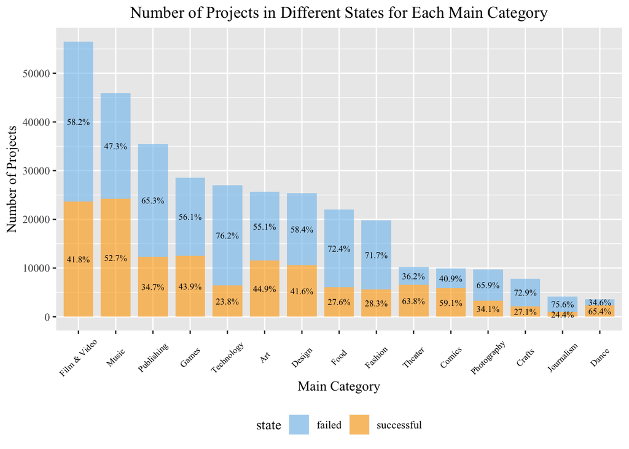

```r
df_b1 = df %>% group_by(main_category,state)  %>% summarise(quantity =  n())
df_b1 = df_b1 %>% mutate(proportion = quantity/sum(quantity))

df_b1 %>%
  ggplot(aes(x=fct_rev(reorder(main_category,quantity)),y = quantity)) +
  geom_bar(aes(fill = state), stat = 'identity', position = 'stack', alpha = 0.6, width = .8) +
  scale_fill_manual(values = c("#7EC0EE", '#FFA500', "black")) +
  geom_text(aes(label = percent(proportion),group = state), position = position_stack(vjust = 0.5), family = "Times New Roman", size = 2.5) +
  theme(axis.text.x = element_text(size = 7, color = "black", face = "plain", vjust = 0.5, hjust = 0.5, angle = 45),plot.title = element_text(hjust = 0.5),text=element_text(family="Times New Roman"), legend.position = "bottom") +
  ggtitle("Number of Projects in Different States for Each Main Category") +
  scale_y_continuous(breaks=seq(0, 60000, 10000))+
  xlab("Main Category") +
  ylab("Number of Projects")
```

**Analysis**

This graph shows the numbers of successful and failed projects among main categories. We wanted to understand whether the types of category will influence projects’ success. We chose to use a bar graph for visualization since category is a discrete variable and the number of projects is a continuous variable. We improved the graph by filling the state to show the proportion of projects in different states in a single bar to get a clear comparison. Based on our visualization, we found that Film &videos has the largest number of projects, meaning there are more projects with funding needs in this industry. Dance has the smallest number of projects and the highest proportion of successful projects. This means Dance industry has strong development prospects. For these categories that have high successful projects proportion but fewer projects, such as Dance, Theater and Comics, kickstarter should increase the number of projects.

**b.Category to goal-reaching ratio**

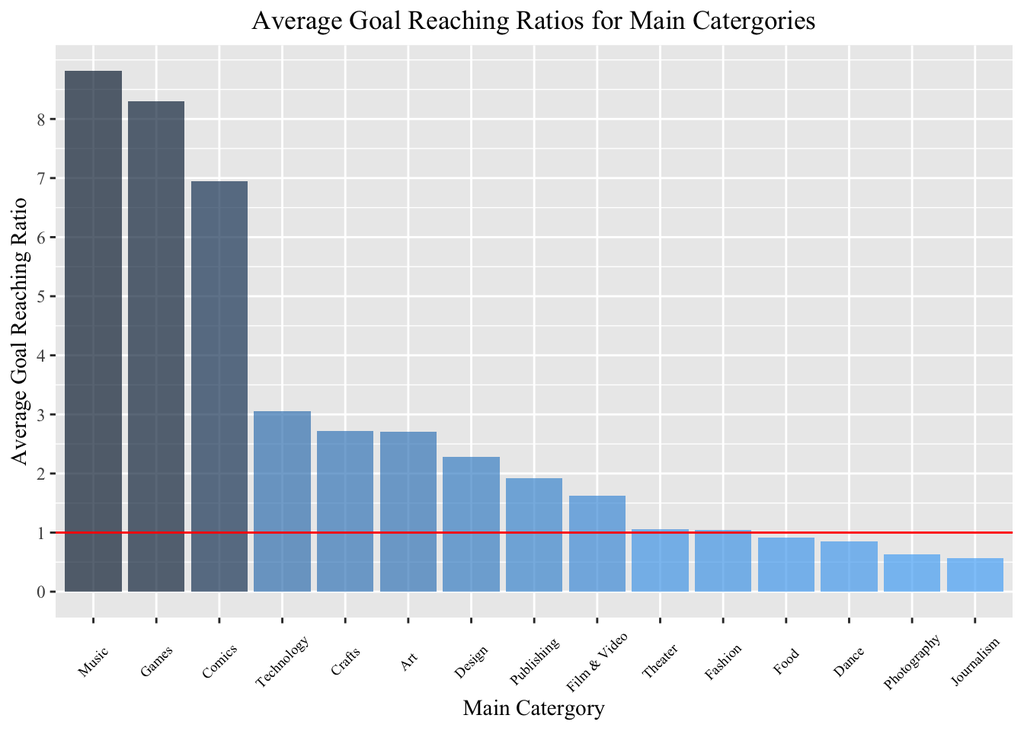

```r
df_b2<-df %>%
    mutate(goal_prop=pledged/goal) %>%
    group_by(main_category) %>%
    summarise(goal_prop_avg=mean(goal_prop)) %>%
    arrange(desc(goal_prop_avg))

df_b2 %>%
  ggplot(aes(x=fct_rev(reorder(main_category,goal_prop_avg)) ,y=goal_prop_avg,fill=goal_prop_avg))+
  geom_bar(stat = 'identity',alpha = 0.7)+
  theme(legend.position="none") +
  ggtitle("Average Goal Reaching Ratios for Main Catergories") +
  xlab("Main Catergory") +
  ylab("Average Goal Reaching Ratio") +
  theme(axis.text.x = element_text(size = 7, color = "black", face = "plain", vjust = 0.5, hjust = 0.5, angle = 45),text=element_text(family="Times New Roman"),plot.title = element_text(hjust = 0.5))+
  scale_y_continuous(breaks=seq(0, 8, 1))+
  geom_hline(aes(yintercept=1),col='Red')+
   scale_fill_continuous(trans = 'reverse')
```

**Analysis**

From the previous analysis, we found that some categories have more successful projects. We decided to further detect whether some categories would be so popular among backers that their pledged amount exceeded their funding goals dramatically. Therefore, we selected category and goal reaching ratio as variables. If the state was successful, the ratio must be larger than 1. In order to do the visualization, we chose the histogram, since main category is nominal and goal reaching ratio is ratio. Therefore, we can compare goal reaching ratio among different main categories clearly. We used different colours for categories to show more contrast. We changed the label interval on the y axis from 2 to 1 and draw a horizontal line to help us distinguish the successful categories from failed ones.

**c.Backers to success**

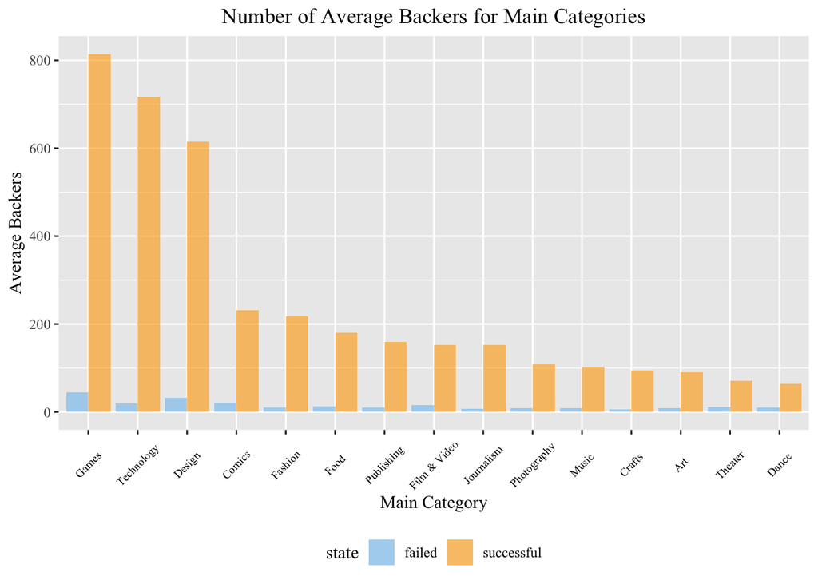

```r
df_b3 <- df %>%
  group_by(main_category,state) %>%
  summarise(Avg_backers = mean( backers))
df_b3 %>%
  ggplot(aes(fct_rev(reorder( main_category,Avg_backers)), y = Avg_backers,fill = state))+
  geom_bar(stat = "identity",alpha = 0.6, position = "dodge") +
  scale_fill_manual(values = c("#7EC0EE", "#FFA500", "black"))+
  ggtitle("Number of Average Backers for Main Categories")+
  theme(axis.text.x = element_text(size = 7, color = "black", face = "plain", vjust = 0.5, hjust = 0.5, angle = 45),plot.title = element_text(hjust = 0.5),legend.position = "bottom",text=element_text(family="Times New Roman"))+
  xlab("Main Category")+
  ylab("Average Backers")
```

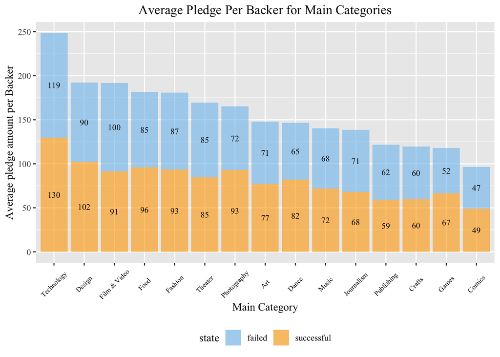

```r
df_b4 <- df %>%
  group_by(main_category, state) %>%
  summarise(Fund_person = sum(pledged)/sum(backers))
df_b4 %>%
  ggplot(aes(fct_rev(reorder(main_category,Fund_person)), y = Fund_person, fill = state))+
  geom_bar(stat= "identity", alpha = 0.6)+
  scale_fill_manual(values = c("#7EC0EE", "#FFA500", "black"))+
  ggtitle("Average Pledge Per Backer for Main Categories")+
  xlab("Main Category")+ ylab("Average pledge amount per Backer")+
  theme(axis.text.x = element_text(size = 7, color = "black", face = "plain", vjust = 0.5, hjust = 0.5, angle = 45),plot.title = element_text(hjust = 0.5),legend.position = "bottom",text=element_text(family="Times New Roman"))+
  geom_text(aes(label = round(Fund_person,0)), position = position_stack(vjust = 0.5), family = "Times New Roman", size = 3)
```

**Analysis**

We wanted to understand what categories attract more backers to pledge and toward which categories backers would like to fund more money. We chose the number of backers and their average pledge amount for each category to measure the appeal of these categories. We used the bar graph to make these two visualizations, since the average backers and the average pledge amount per backer are continuous variables, and main category is a discrete variable. Moreover, within categories we compared the avergae backers and average pledge amount between successful and failed projects. Based on these visualizations, we found that Games, Technology and Design have the largest number of the backers and are popular among backers. According to the second visualization, the Technology category has the second largest number of backers and the highest pledge amount per backer. Technology is a popular category that Kickstarter should invite more projects. For those categories with higher average pledge amount but lower number of backers, such as Film & Video, Theater, Photography and Art, backers are more generous to invest.

**d.The relationship between goal and success**

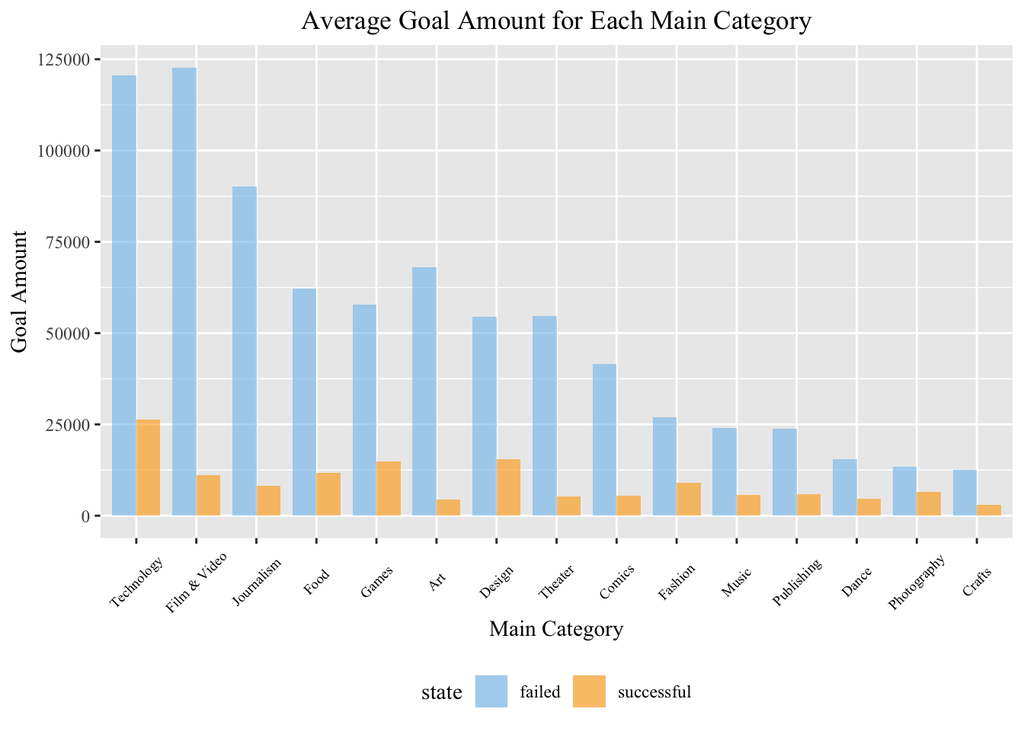

```r
df_b5 = df %>% group_by(main_category,state)  %>% summarise(avg_goal =  mean(goal))
df_b5 %>% ggplot(aes(x = fct_rev(reorder(main_category, avg_goal)), y = avg_goal)) +
  geom_bar(aes(fill = state), stat = 'identity', position = 'dodge',alpha = 0.6, width = .8)+
  theme(axis.text.x = element_text(size = 7, color = "black", face = "plain", vjust = 0.5, hjust = 0.5, angle = 45),plot.title = element_text(hjust = 0.5),legend.position = "bottom",text=element_text(family="Times New Roman"))+
  scale_fill_manual(values = c("#7EC0EE", '#FFA500', "black"))+
   ggtitle("Average Goal Amount for Each Main Category") +
   xlab("Main Category") +
  ylab("Goal Amount")
```

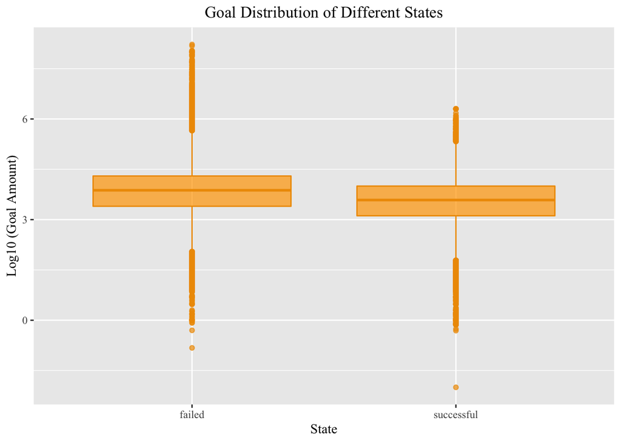

```r
options(scipen=999)
df %>%
  ggplot(aes(x=state,y=log10(goal)))+
  geom_boxplot(fill ='#FFA500', colour = "#EE9A00",alpha=.7) +
  xlab('State')+
  ylab('Log10 (Goal Amount)')+
  labs(title = "Goal Distribution of Different States") +
  theme(plot.title = element_text(hjust = 0.5),text=element_text(family="Times New Roman"))+
  scale_fill_continuous(label=comma)
```

**Analysis**

We wanted to find whether the goals were different between successful and failed projects. In the first graph, among all the categories, the goal amounts of successful projects were much smaller. In the second graph, we used the boxplot for the visualization of goal distribution, since goal is ratio and state is nominal. Because of the outliers, we applied log function to goal amount for showing the box clearly. We found that in the successful projects, goal distribution had a smaller range with a lower position compared to the failed projects. Therefore, we came to a conclusion that setting a smaller, reasonable and affordable goal can help projects to take steps toward a successful state, and establish trust with crowd funders.

**2)Summary statistics**  
At the end of this part, we took a look at the countries where the five biggest numbers of projects are from.The biggest number of projects is from United States, which is 79% of total projects.

```r
df_b5 = df %>%
  group_by(country) %>% summarise(`number of projects` = n_distinct(ID)) %>% top_n(5) %>% arrange(desc(`number of projects`)) %>% kable()
df_b5
```

| country | number of projects |
| --- | --- |
| US | 261360 |
| GB | 29454 |
| CA | 12370 |
| AU | 6616 |
| DE | 3436 |

#### 4.Preliminary statistical analysis

**a.Chi-squared test: association between category and state**

```r
table(df$main_category, df$state)
```

```
##
##                failed successful
##   Art           14131      11510
##   Comics         4036       5842
##   Crafts         5703       2115
##   Dance          1235       2338
##   Design        14814      10550
##   Fashion       14182       5593
##   Film & Video  32904      23623
##   Food          15969       6085
##   Games         16003      12518
##   Journalism     3137       1012
##   Music         21752      24197
##   Photography    6384       3305
##   Publishing    23145      12300
##   Technology    20616       6434
##   Theater        3708       6534
```

```r
chisq.test(table(df$main_category, df$state))
```

```
##
##  Pearson's Chi-squared test
##
## data:  table(df$main_category, df$state)
## X-squared = 15455, df = 14, p-value < 0.00000000000000022
```

Under 95% confidence level, p-value < 2.2e-16, so we rejected the null hypothesis. Category and state have a statistically significant association. This further proves our finding in the visualization 3.a that different categories have different proportion of failed and successful projects.

**b.T-test for category groups with different goal-reaching ability**

Based on the graph in 3.b, we knew that the goal-reaching ratio (pledged/goal) is different between categories. To verify whether this difference is statistically significant, we used T-test because ratio is a continuous variable. We compared different observations within one variable using independent T-test.

We devided 15 categories into three groups because we wanted to provide recommendations to Kickstarter about which categories should be prompted as top priority.

```r
#Grouping
df_high <- df %>% filter(main_category == ' Music'| main_category== 'Games'|main_category== 'Comics'|main_category=='Technology'|main_category=='Art')%>% mutate(ratio = pledged/goal)

df_medium <- df %>% filter(main_category == 'Crafts'| main_category== 'Design'|main_category== 'Publishing'|main_category=='Film & Video'|main_category=='Fashion') %>% mutate(ratio = pledged/goal)

df_low <- df %>% filter(main_category == 'Journalism'| main_category== 'Photography'|main_category== 'Dance'|main_category=='Food'|main_category=='Theater') %>% mutate(ratio = pledged/goal)
```

Hypothesis 1:
$$H_0: \mu_{highratio} = \mu_{mediumratio}; \; \; H_A: \mu_{highratio} \neq \mu_{mediumratio}$$

```r
###Hypothesis 1
table = data.frame(matrix(nrow=1,ncol=4))
colnames(table) = c("Variable","Mean for high categories","Mean for medium categories","p-value")
test_1 = t.test(df_high$ratio, df_medium$ratio, paired = FALSE)
table[1,]=c("Ratio",round(as.numeric(test_1$estimate[1]),4),round(as.numeric(test_1$estimate[2]),4),round(as.numeric(test_1$p.value),4))
kable(table)
```

| Variable | Mean for high categories | Mean for medium categories | p-value |
| --- | --- | --- | --- |
| Ratio | 5.0218 | 1.7904 | 0.0001 |

Hypothesis 2:
$$H_0: \mu_{highratio} = \mu_{lowratio}; \; \; H_A: \mu_{highratio} \neq \mu_{lowratio}$$

```r
###Hypothesis 2
table = data.frame(matrix(nrow=1,ncol=4))
colnames(table) = c("Variable","Mean for high categories","Mean for low categories","p-value")
test_2 = t.test(df_high$ratio, df_low$ratio, paired = FALSE)
table[1,]=c("Ratio",round(as.numeric(test_2$estimate[1]),4),round(as.numeric(test_2$estimate[2]),4),round(as.numeric(test_2$p.value),4))
kable(table)
```

| Variable | Mean for high categories | Mean for low categories | p-value |
| --- | --- | --- | --- |
| Ratio | 5.0218 | 0.8572 | 0 |

Hypothesis 3:
$$H_0: \mu_{lowratio} = \mu_{mediumratio}; \; \; H_A: \mu_{lowratio} \neq \mu_{mediumratio}$$

```r
###Hypothesis 3
table = data.frame(matrix(nrow=1,ncol=4))
colnames(table) = c("Variable","Mean for low categories","Mean for medium categories","p-value")
test_3 = t.test(df_low$ratio, df_medium$ratio, paired = FALSE)
table[1,]=c("Ratio",round(as.numeric(test_3$estimate[1]),4),round(as.numeric(test_3$estimate[2]),4),round(as.numeric(test_3$p.value),4))
kable(table)
```

| Variable | Mean for low categories | Mean for medium categories | p-value |
| --- | --- | --- | --- |
| Ratio | 0.8572 | 1.7904 | 0.0005 |

For these 3 T-tests, all the p-values are smaller than 0.01, so we reject the Null Hypothesis that the mean of ratio between high and medium, high and low, low and medium are respectively equal. In conclusion, average goal-reaching ratios between groups of different categories are statistically significant at 99% confidence level.

**c.T-test for number of backers between successful and failed projects**

Based on the graph in 3.c, we knew that the average backer numbers of the successful projects are much more than the failed projects. To verify whether this difference is statistically significant, we used T-test because backers is a continuous variable. We compared different observations within one variable using independent T-test.

Hypothesis:
$$H_0: \mu_{Sbackers} = \mu_{Fbackers}; \; \; H_A: \mu_{Sbackers} \neq \mu_{Fbackers}$$

```r
df_successful<-df %>% filter(state=='successful')
df_failed<-df %>%filter(state=='failed')
###Table
table = data.frame(matrix(nrow=1,ncol=4))
colnames(table) = c("Variable","Mean for successful projects","Mean for failed projects","p-value")
test_4 = t.test(df_successful$backers, df_failed$backers, paired = FALSE)
table[1,]=c("Backers",round(as.numeric(test_4$estimate[1]),4),round(as.numeric(test_4$estimate[2]),4),round(as.numeric(test_4$p.value),4))
kable(table)
```

| Variable | Mean for successful projects | Mean for failed projects | p-value |
| --- | --- | --- | --- |
| Backers | 263.9214 | 16.4224 | 0 |

The extremely small p-value in the test result states that the average backer numbers are significantly different between successful and failed projects. Averagely, a successful project had 264 backers and a failed project had 16 backers. In conclusion, Kickstarter should attract more backers by promotion events.

**d.t-test for funding goal, pledge amount and goal-reaching ratio between successful and failed groups**

To further analyze the difference between successful and failed projects, we conducted 3 more independent T-tests to see whether their goal, pledge amount and goal-reaching ability are statistically different.  
We used independent T-tests in this analysis as well.

Hypothesis 1:
$$H_0: \mu_{Sgoal} = \mu_{Fgoal}; \; \; H_A: \mu_{Sgoal} \neq \mu_{Fgoal}$$
Hypothesis 2:
$$H_0: \mu_{Spledged} = \mu_{Fpledged}; \; \; H_A: \mu_{Spledged} \neq \mu_{Fpledged}$$
Hypothesis 3:
$$H_0: \mu_{Sratio} = \mu_{Fratio}; \; \; H_A: \mu_{Sratio} \neq \mu_{Fratio}$$

```r
#c: table
ttests = list(NULL)
ttests[[1]] = t.test(df_successful$goal, df_failed$goal, paired = FALSE)
ttests[[2]] = t.test(df_successful$pledged, df_failed$pledged, paired = FALSE)
ttests[[3]] = t.test(df_successful$goalreachingratio, df_failed$goalreachingratio, paired = FALSE)
means = t(sapply(1:3, function(i){ttests[[i]]$estimate}))
tab = data.frame(Variables = c('Goal','Pledged','Goal reaching ratio'),
                 `Mean successful ` = means[,1],
                 `Mean failed ` = means[,2],
                 `p-value` = sapply(1:3, function(i){ttests[[i]]$p.value}))
knitr::kable(tab)
```

| Variables | Mean.successful. | Mean.failed. | p.value |
| --- | --- | --- | --- |
| Goal | 9532.85336 | 63174.7422220 | 0 |
| Pledged | 22670.79523 | 1320.6038168 | 0 |
| Goal reaching ratio | 8.55795 | 0.0906201 | 0 |

Because these three p-values are extremely small, we concluded that goal, pledge amount, and goal_reaching ratio are statistically different between successful projects and failed projects. In conclusion, a successful project has lower goal, higher pledged amount and much higher goal-reaching ability on average.

#### 5.Regression Analysis

**a.Logistic Regression**

```r
#run a logistic regression
logres = glm(isSuccessful ~ goal+backers+main_category,data = df, family = binomial)
summary(logres)
```

```
##
## Call:
## glm(formula = isSuccessful ~ goal + backers + main_category,
##     family = binomial, data = df)
##
## Deviance Residuals:
##     Min       1Q   Median       3Q      Max
## -8.4904  -0.5556  -0.0265   0.2907   8.4904
##
## Coefficients:
##                               Estimate   Std. Error  z value
## (Intercept)               -0.673823123  0.016555934  -40.700
## goal                      -0.000232694  0.000001271 -183.120
## backers                    0.055506751  0.000238859  232.383
## main_categoryComics       -0.543818565  0.035827147  -15.179
## main_categoryCrafts       -0.664748175  0.036275708  -18.325
## main_categoryDance         0.705159154  0.047345395   14.894
## main_categoryDesign       -0.656614307  0.028952848  -22.679
## main_categoryFashion      -0.593053998  0.028057479  -21.137
## main_categoryFilm & Video  0.206021605  0.020434656   10.082
## main_categoryFood         -0.463739913  0.028920798  -16.035
## main_categoryGames        -1.563679317  0.030888449  -50.623
## main_categoryJournalism   -0.662539432  0.052788275  -12.551
## main_categoryMusic         0.113863006  0.020724535    5.494
## main_categoryPhotography  -0.402457116  0.033078654  -12.167
## main_categoryPublishing   -0.545279548  0.023035333  -23.671
## main_categoryTechnology   -0.624669194  0.031713218  -19.697
## main_categoryTheater       0.716295779  0.031389815   22.819
##                                       Pr(>|z|)
## (Intercept)               < 0.0000000000000002 ***
## goal                      < 0.0000000000000002 ***
## backers                   < 0.0000000000000002 ***
## main_categoryComics       < 0.0000000000000002 ***
## main_categoryCrafts       < 0.0000000000000002 ***
## main_categoryDance        < 0.0000000000000002 ***
## main_categoryDesign       < 0.0000000000000002 ***
## main_categoryFashion      < 0.0000000000000002 ***
## main_categoryFilm & Video < 0.0000000000000002 ***
## main_categoryFood         < 0.0000000000000002 ***
## main_categoryGames        < 0.0000000000000002 ***
## main_categoryJournalism   < 0.0000000000000002 ***
## main_categoryMusic                0.0000000393 ***
## main_categoryPhotography  < 0.0000000000000002 ***
## main_categoryPublishing   < 0.0000000000000002 ***
## main_categoryTechnology   < 0.0000000000000002 ***
## main_categoryTheater      < 0.0000000000000002 ***
## ---
## Signif. codes:  0 '***' 0.001 '**' 0.01 '*' 0.05 '.' 0.1 ' ' 1
##
## (Dispersion parameter for binomial family taken to be 1)
##
##     Null deviance: 447464  on 331674  degrees of freedom
## Residual deviance: 206633  on 331658  degrees of freedom
## AIC: 206667
##
## Number of Fisher Scoring iterations: 25
```

**Analysis**  
Continuing our analysis of funding state, we conducted a logistic model to see how the goal, backers and main category affect the log odds (p(successful)/p(y=failed)) of success. We regressed isSuccessful on goal, backers and main_category. From the regression result, all the regressors are significant. It means that goal, backers and main category affect the log odds of success.  
We can see that the probability of success for each category varies a lot. Intercept represents the Art category. Holding goal and backers same, Theater, Dance, Film & Video and Music are the top 4 categories that have a high probability to be successful, known from their positive and relatively high coefficients. While the Games category has the lowest coefficient, indicating that it had the smallest probability to succeed among all categories.

**b.Linear Regression**

**baseline linear regression**

```r
reg_baseline = lm(pledged~goal+backers, data = df)
summary(reg_baseline)
```

```
##
## Call:
## lm(formula = pledged ~ goal + backers, data = df)
##
## Residuals:
##      Min       1Q   Median       3Q      Max
## -7754741    -1821    -1265    -1138 14422884
##
## Coefficients:
##                  Estimate    Std. Error t value            Pr(>|t|)
## (Intercept) 1162.25514209  111.53545760   10.42 <0.0000000000000002 ***
## goal           0.00021253    0.00009979    2.13              0.0332 *
## backers       75.37605027    0.11462445  657.59 <0.0000000000000002 ***
## ---
## Signif. codes:  0 '***' 0.001 '**' 0.01 '*' 0.05 '.' 0.1 ' ' 1
##
## Residual standard error: 63730 on 331672 degrees of freedom
## Multiple R-squared:  0.5659, Adjusted R-squared:  0.5659
## F-statistic: 2.162e+05 on 2 and 331672 DF,  p-value: < 0.00000000000000022
```

```r
confint(reg_baseline, level=0.95)
```

```
##                       2.5 %          97.5 %
## (Intercept) 943.64886444548 1380.8614197400
## goal          0.00001694344    0.0004081197
## backers      75.15138964973   75.6007108907
```

**Analysis**

This is our baseline regression. By running this regression, we wanted to test whether the goal and backer numbers of projects will influence the pledged amount. We regressed pledged on goal and backers. We found that backers was significant at any confidence level and goal was significant at 95% confidence level. If the goal goes up by one unit, average pledged amount will go up by 0.0002 dollars holding backer numbers constant. If the backers goes up by one unit, the average pledged amount will go up by 75 dollars holding the goal constant. For this regression, the Adjusted R squared is 0.566, which means our regression model is acceptable.

**Adding main_category x backers interaction into regression**

```r
lm_inter = lm(pledged~goal+backers+factor(main_category)+factor(main_category)*backers,data = df)
summary(lm_inter)
```

```
##
## Call:
## lm(formula = pledged ~ goal + backers + factor(main_category) +
##     factor(main_category) * backers, data = df)
##
## Residuals:
##       Min        1Q    Median        3Q       Max
## -10447803     -1835      -938       226  11773147
##
## Coefficients:
##                                                 Estimate     Std. Error
## (Intercept)                                 120.07006073   386.75638624
## goal                                          0.00020696     0.00009505
## backers                                      73.66062361     1.69896051
## factor(main_category)Comics               -1321.75958505   754.99199322
## factor(main_category)Crafts                 403.84876587   796.45324933
## factor(main_category)Dance                 1188.67607535  1200.18252604
## factor(main_category)Design               -2255.54889541   546.51749259
## factor(main_category)Fashion               1367.41656065   585.12429439
## factor(main_category)Film & Video          1399.06770272   464.50131495
## factor(main_category)Food                  -459.80788475   569.59129602
## factor(main_category)Games                 1682.39951012   531.02046574
## factor(main_category)Journalism             259.60903642  1048.79292854
## factor(main_category)Music                  770.54031347   485.70469284
## factor(main_category)Photography           -627.65148023   752.32261602
## factor(main_category)Publishing             787.53644360   507.50265156
## factor(main_category)Technology            8935.60943064   537.45178808
## factor(main_category)Theater                 88.84448737   768.81232711
## backers:factor(main_category)Comics         -16.35121417     2.26595141
## backers:factor(main_category)Crafts         -31.48955890     4.28083370
## backers:factor(main_category)Dance          -22.26088069    11.51600465
## backers:factor(main_category)Design          35.52457156     1.71430467
## backers:factor(main_category)Fashion         -2.60910174     2.07196997
## backers:factor(main_category)Film & Video    -2.26887627     1.75623551
## backers:factor(main_category)Food            26.36767311     2.27136992
## backers:factor(main_category)Games          -12.78421595     1.70561444
## backers:factor(main_category)Journalism     -14.53915273     6.06609310
## backers:factor(main_category)Music          -17.47177434     2.17219085
## backers:factor(main_category)Photography     28.05865521     4.72695766
## backers:factor(main_category)Publishing     -28.68484594     1.99025682
```

[output cut: 25 more lines]

```
## backers:factor(main_category)Film & Video  -1.292             0.196394
## backers:factor(main_category)Food          11.609 < 0.0000000000000002 ***
## backers:factor(main_category)Games         -7.495 0.000000000000066273 ***
## backers:factor(main_category)Journalism    -2.397             0.016540 *
## backers:factor(main_category)Music         -8.043 0.000000000000000877 ***
## backers:factor(main_category)Photography    5.936 0.000000002925618432 ***
## backers:factor(main_category)Publishing   -14.413 < 0.0000000000000002 ***
## backers:factor(main_category)Technology     3.702             0.000214 ***
## backers:factor(main_category)Theater        1.109             0.267587
## ---
## Signif. codes:  0 '***' 0.001 '**' 0.01 '*' 0.05 '.' 0.1 ' ' 1
##
## Residual standard error: 60680 on 331644 degrees of freedom
## Multiple R-squared:  0.6065, Adjusted R-squared:  0.6065
## F-statistic: 1.704e+04 on 30 and 331644 DF,  p-value: < 0.00000000000000022
```

**Analysis**

In this regression, we wanted to know whether the main category will affect pledge amount and backer numbers. We added main_category and main_category*backers into independent variables based on the baseline regression. After running this regression, we found that adjusted R squared was increased from 0.5659 to 0.6065.